# Credit Card Segmentation (Clustering Project Work) - Prabhu _4Dec2020

## AllLife Credit Card Customer Segmentation

Background: AllLife Bank wants to focus on its credit card customer base in the next financial year. They have been advised by their marketing research team, that the penetration in the market can be improved. Based on this input, the Marketing team proposes to run personalised campaigns to target new customers as well as upsell to existing customers. Another insight from the market research was that the customers perceive the support services of the back poorly. Based on this, the Operations team wants to upgrade the service delivery model, to ensure that customers queries are resolved faster. Head of Marketing and Head of Delivery both decide to reach out to the Data Science team for help.

### Objective:

To identify different segments in the existing customer based on their spending patterns as well as past interaction with the bank.

#### Key Questions:

1. How many different segments of customers are there?
2. How are these segments different from each other?
3. What are your recommendations to the bank on how to better market to and service these customers?

#### Data Description:

Data is of various customers of a bank with their credit limit, the total number of credit cards the customer has, and different channels through which customer has contacted the bank for any queries, different channels include visiting the bank, online and through a call centre.

#### Steps to follow:

1. Perform univariate analysis on the data to better understand the variables at your disposal and to get an idea about the no of clusters. Perform EDA, create visualizations to explore data. (10 marks)
2. Properly comment on the codes, provide explanations of the steps taken in the notebook and conclude your insights from the graphs. (5 marks)
3. Execute K-means clustering use elbow plot and analyse clusters using boxplot (10 marks)
4. Execute hierarchical clustering (with different linkages) with the help of dendrogram and cophenetic coeff. Analyse clusters formed using boxplot (15 marks)
5. Calculate average silhouette score for both methods. (5 marks)
6. Compare K-means clusters with Hierarchical clusters. (5 marks)
7. Analysis the clusters formed, tell us how is one cluster different from another and answer all the key questions. (10 marks)

```python
import warnings
warnings.filterwarnings('ignore')
```

```python
#Import all the necessary modules
import pandas as pd
import numpy as np
import os
import seaborn as sns
import matplotlib.pyplot as plt
from sklearn.model_selection import train_test_split
from sklearn.cluster import KMeans
%matplotlib inline
```

```python
# Import Data - excel file
data_df = pd.read_excel("Credit Card Customer Data.xlsx")
data_df.head(10)
```

|  | Sl_No | Customer Key | Avg_Credit_Limit | Total_Credit_Cards | Total_visits_bank | Total_visits_online | Total_calls_made |
| --- | --- | --- | --- | --- | --- | --- | --- |
| 0 | 1 | 87073 | 100000 | 2 | 1 | 1 | 0 |
| 1 | 2 | 38414 | 50000 | 3 | 0 | 10 | 9 |
| 2 | 3 | 17341 | 50000 | 7 | 1 | 3 | 4 |
| 3 | 4 | 40496 | 30000 | 5 | 1 | 1 | 4 |
| 4 | 5 | 47437 | 100000 | 6 | 0 | 12 | 3 |
| 5 | 6 | 58634 | 20000 | 3 | 0 | 1 | 8 |
| 6 | 7 | 48370 | 100000 | 5 | 0 | 11 | 2 |
| 7 | 8 | 37376 | 15000 | 3 | 0 | 1 | 1 |
| 8 | 9 | 82490 | 5000 | 2 | 0 | 2 | 2 |
| 9 | 10 | 44770 | 3000 | 4 | 0 | 1 | 7 |

```python
data_df.shape
```

```
(660, 7)
```

```python
data_df.dtypes
```

```
Sl_No                  int64
Customer Key           int64
Avg_Credit_Limit       int64
Total_Credit_Cards     int64
Total_visits_bank      int64
Total_visits_online    int64
Total_calls_made       int64
dtype: object
```

```python
data_df.nunique()
```

```
Sl_No                  660
Customer Key           655
Avg_Credit_Limit       110
Total_Credit_Cards      10
Total_visits_bank        6
Total_visits_online     16
Total_calls_made        11
dtype: int64
```

```python
data_df.describe()
```

|  | Sl_No | Customer Key | Avg_Credit_Limit | Total_Credit_Cards | Total_visits_bank | Total_visits_online | Total_calls_made |
| --- | --- | --- | --- | --- | --- | --- | --- |
| count | 660.000000 | 660.000000 | 660.000000 | 660.000000 | 660.000000 | 660.000000 | 660.000000 |
| mean | 330.500000 | 55141.443939 | 34574.242424 | 4.706061 | 2.403030 | 2.606061 | 3.583333 |
| std | 190.669872 | 25627.772200 | 37625.487804 | 2.167835 | 1.631813 | 2.935724 | 2.865317 |
| min | 1.000000 | 11265.000000 | 3000.000000 | 1.000000 | 0.000000 | 0.000000 | 0.000000 |
| 25% | 165.750000 | 33825.250000 | 10000.000000 | 3.000000 | 1.000000 | 1.000000 | 1.000000 |
| 50% | 330.500000 | 53874.500000 | 18000.000000 | 5.000000 | 2.000000 | 2.000000 | 3.000000 |
| 75% | 495.250000 | 77202.500000 | 48000.000000 | 6.000000 | 4.000000 | 4.000000 | 5.000000 |
| max | 660.000000 | 99843.000000 | 200000.000000 | 10.000000 | 5.000000 | 15.000000 | 10.000000 |

```python
data_df.describe().T
```

|  | count | mean | std | min | 25% | 50% | 75% | max |
| --- | --- | --- | --- | --- | --- | --- | --- | --- |
| Sl_No | 660.0 | 330.500000 | 190.669872 | 1.0 | 165.75 | 330.5 | 495.25 | 660.0 |
| Customer Key | 660.0 | 55141.443939 | 25627.772200 | 11265.0 | 33825.25 | 53874.5 | 77202.50 | 99843.0 |
| Avg_Credit_Limit | 660.0 | 34574.242424 | 37625.487804 | 3000.0 | 10000.00 | 18000.0 | 48000.00 | 200000.0 |
| Total_Credit_Cards | 660.0 | 4.706061 | 2.167835 | 1.0 | 3.00 | 5.0 | 6.00 | 10.0 |
| Total_visits_bank | 660.0 | 2.403030 | 1.631813 | 0.0 | 1.00 | 2.0 | 4.00 | 5.0 |
| Total_visits_online | 660.0 | 2.606061 | 2.935724 | 0.0 | 1.00 | 2.0 | 4.00 | 15.0 |
| Total_calls_made | 660.0 | 3.583333 | 2.865317 | 0.0 | 1.00 | 3.0 | 5.00 | 10.0 |

```python
data_df.isna().sum() #check for null Values
```

```
Sl_No                  0
Customer Key           0
Avg_Credit_Limit       0
Total_Credit_Cards     0
Total_visits_bank      0
Total_visits_online    0
Total_calls_made       0
dtype: int64
```

# EDA

```python
# Drop id and class variables
data_new = data_df.drop(['Sl_No', 'Customer Key'], axis =1)
data_new.head()
```

|  | Avg_Credit_Limit | Total_Credit_Cards | Total_visits_bank | Total_visits_online | Total_calls_made |
| --- | --- | --- | --- | --- | --- |
| 0 | 100000 | 2 | 1 | 1 | 0 |
| 1 | 50000 | 3 | 0 | 10 | 9 |
| 2 | 50000 | 7 | 1 | 3 | 4 |
| 3 | 30000 | 5 | 1 | 1 | 4 |
| 4 | 100000 | 6 | 0 | 12 | 3 |

```python
data_new.isna().sum()
```

```
Avg_Credit_Limit       0
Total_Credit_Cards     0
Total_visits_bank      0
Total_visits_online    0
Total_calls_made       0
dtype: int64
```

```python
data_new.describe()
```

|  | Avg_Credit_Limit | Total_Credit_Cards | Total_visits_bank | Total_visits_online | Total_calls_made |
| --- | --- | --- | --- | --- | --- |
| count | 660.000000 | 660.000000 | 660.000000 | 660.000000 | 660.000000 |
| mean | 34574.242424 | 4.706061 | 2.403030 | 2.606061 | 3.583333 |
| std | 37625.487804 | 2.167835 | 1.631813 | 2.935724 | 2.865317 |
| min | 3000.000000 | 1.000000 | 0.000000 | 0.000000 | 0.000000 |
| 25% | 10000.000000 | 3.000000 | 1.000000 | 1.000000 | 1.000000 |
| 50% | 18000.000000 | 5.000000 | 2.000000 | 2.000000 | 3.000000 |
| 75% | 48000.000000 | 6.000000 | 4.000000 | 4.000000 | 5.000000 |
| max | 200000.000000 | 10.000000 | 5.000000 | 15.000000 | 10.000000 |

```python
data_new.describe().T
```

|  | count | mean | std | min | 25% | 50% | 75% | max |
| --- | --- | --- | --- | --- | --- | --- | --- | --- |
| Avg_Credit_Limit | 660.0 | 34574.242424 | 37625.487804 | 3000.0 | 10000.0 | 18000.0 | 48000.0 | 200000.0 |
| Total_Credit_Cards | 660.0 | 4.706061 | 2.167835 | 1.0 | 3.0 | 5.0 | 6.0 | 10.0 |
| Total_visits_bank | 660.0 | 2.403030 | 1.631813 | 0.0 | 1.0 | 2.0 | 4.0 | 5.0 |
| Total_visits_online | 660.0 | 2.606061 | 2.935724 | 0.0 | 1.0 | 2.0 | 4.0 | 15.0 |
| Total_calls_made | 660.0 | 3.583333 | 2.865317 | 0.0 | 1.0 | 3.0 | 5.0 | 10.0 |

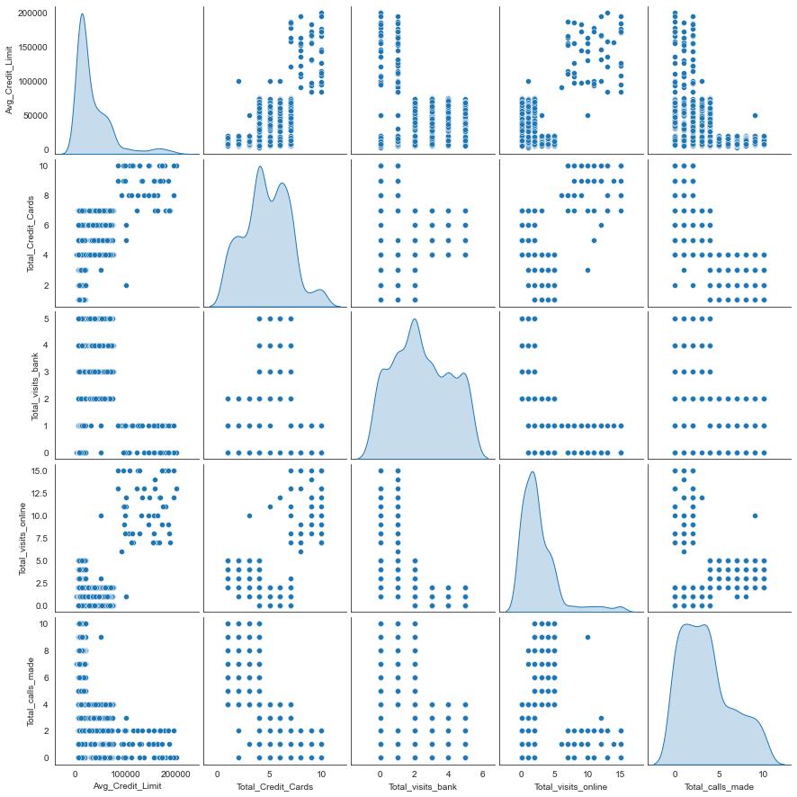

```python
sns.pairplot(data_new, diag_kind='kde')
```

# Univariate & Bivariate Analysis

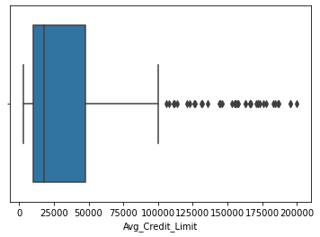

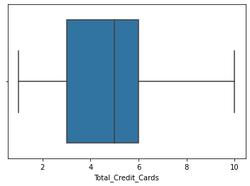

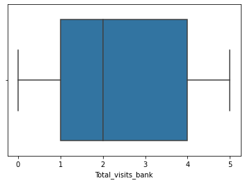

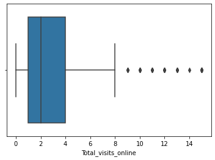

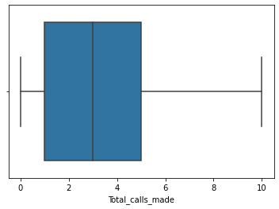

```python
# Checking for Outlier using boxplot for continous columns
# Below box plot especially for "Avg_Credit_Limit" shows few customers have high credit limit - These are not outliers - decided to keep the values
for i in ['Avg_Credit_Limit','Total_Credit_Cards','Total_visits_bank', 'Total_visits_online', 'Total_calls_made']:
    sns.boxplot(data_new[i])
    plt.show()
```

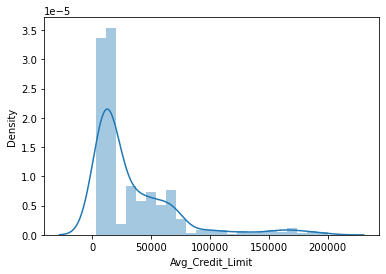

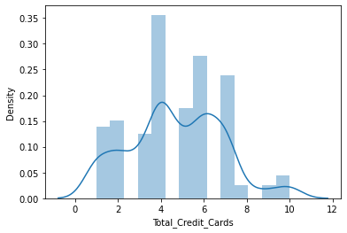

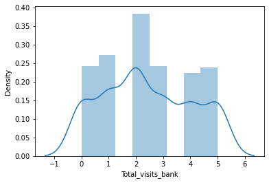

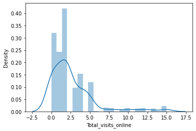

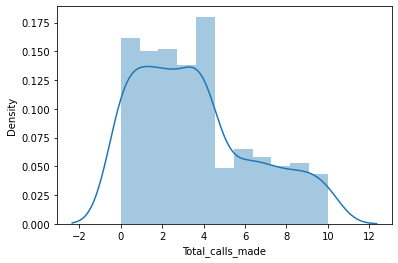

```python
# distplot for continous columns
# Below distplot also for "Avg_Credit_Limit" shows few customers have high credit limit - These are not outliers - decided to keep the values
for i in ['Avg_Credit_Limit','Total_Credit_Cards','Total_visits_bank', 'Total_visits_online', 'Total_calls_made']:
    sns.distplot(data_new[i])
    plt.show()
```

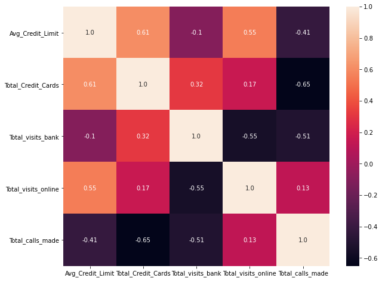

```python
# using correlation methoid to see different correlation between the variables
plt.figure(figsize=(10,8))
sns.heatmap(data_new.corr(), annot=True, fmt=".2")
plt.show()
```

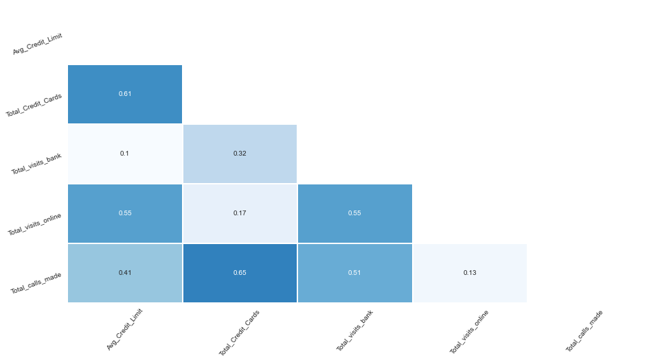

```python
corr = abs(data_new.corr()) # correlation matrix
lower_triangle = np.tril(corr, k = -1)  # select only the lower triangle of the correlation matrix
mask = lower_triangle == 0  # to mask the upper triangle in the following heatmap

plt.figure(figsize = (15,8))  # setting the figure size
sns.set_style(style = 'white')  # Setting it to white so that we do not see the grid lines
sns.heatmap(lower_triangle, center=0.5, cmap= 'Blues', annot= True, xticklabels = corr.index, yticklabels = corr.columns,
            cbar= False, linewidths= 1, mask = mask)   # Da Heatmap
plt.xticks(rotation = 50)   # Aesthetic purposes
plt.yticks(rotation = 20)   # Aesthetic purposes
plt.show()
```

```python
# As "Avg_Credit_Limit" as high values using Z- score scaling to standardize the data
#from scipy.stats import zscore
#data_new=data_new.apply(zscore)
#data_new.head()

##Scale the data
from scipy.stats import zscore
data_new_z = data_new.apply(zscore)
```

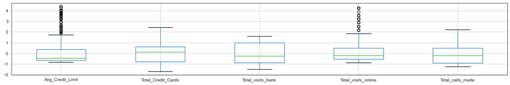

```python
data_new_z.boxplot(figsize=(20,3))
```

```python
data_new_z.describe()
```

|  | Avg_Credit_Limit | Total_Credit_Cards | Total_visits_bank | Total_visits_online | Total_calls_made |
| --- | --- | --- | --- | --- | --- |
| count | 6.600000e+02 | 6.600000e+02 | 6.600000e+02 | 6.600000e+02 | 6.600000e+02 |
| mean | 8.195465e-16 | -4.002522e-15 | 1.264981e-16 | 1.944572e-16 | -6.762268e-16 |
| std | 1.000758e+00 | 1.000758e+00 | 1.000758e+00 | 1.000758e+00 | 1.000758e+00 |
| min | -8.398081e-01 | -1.710864e+00 | -1.473731e+00 | -8.883795e-01 | -1.251537e+00 |
| 25% | -6.536229e-01 | -7.875852e-01 | -8.604506e-01 | -5.474897e-01 | -9.022711e-01 |
| 50% | -4.408398e-01 | 1.356941e-01 | -2.471705e-01 | -2.065999e-01 | -2.037386e-01 |
| 75% | 3.570968e-01 | 5.973337e-01 | 9.793898e-01 | 4.751797e-01 | 4.947938e-01 |
| max | 4.399975e+00 | 2.443892e+00 | 1.592670e+00 | 4.224968e+00 | 2.241125e+00 |

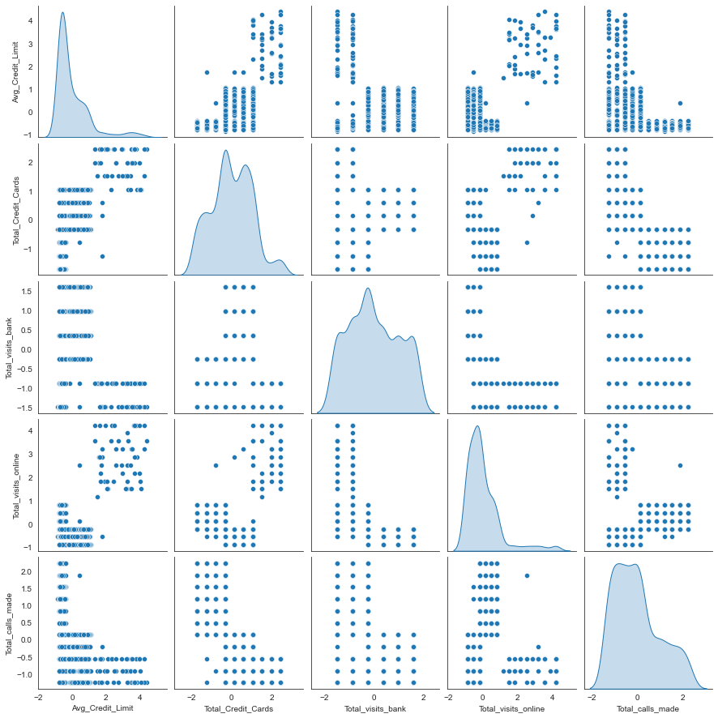

```python
sns.pairplot(data_new_z, diag_kind='kde')
```

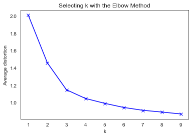

```python
#Finding optimal no. of clusters
from scipy.spatial.distance import cdist
clusters=range(1,10)
meanDistortions=[]

for k in clusters:
    model=KMeans(n_clusters=k)
    model.fit(data_new)
    prediction=model.predict(data_new)
    meanDistortions.append(sum(np.min(cdist(data_new_z, model.cluster_centers_, 'euclidean'), axis=1)) / data_new
                           .shape[0])


plt.plot(clusters, meanDistortions, 'bx-')
plt.xlabel('k')
plt.ylabel('Average distortion')
plt.title('Selecting k with the Elbow Method')
```

```python
#Set the value of k=6
kmeans = KMeans(n_clusters=6, n_init = 15, random_state=2345)
```

```python
kmeans.fit(data_new_z)
```

```
KMeans(n_clusters=6, n_init=15, random_state=2345)
```

```python
centroids = kmeans.cluster_centers_
```

```python
#Clculate the centroids for the columns to profile
centroid_df = pd.DataFrame(centroids, columns = list(data_new_z) )
```

```python
print(centroid_df)
```

```
   Avg_Credit_Limit  Total_Credit_Cards  Total_visits_bank  \
0         -0.592426           -1.084085          -0.935241
1         -0.423759            0.423689           0.056656
2          2.831764            1.862226          -1.105763
3         -0.198037            0.348966           1.330860
4          0.678530            0.362159           0.221468
5         -0.599900           -1.029832          -0.860451

   Total_visits_online  Total_calls_made
0             0.347692          1.681731
1            -0.556872         -0.546596
2             2.827319         -0.874330
3            -0.531542         -0.567302
4            -0.586081         -0.536530
5             0.292922          0.498252
```

```python
## creating a new dataframe only for labels and converting it into categorical variable
df_labels = pd.DataFrame(kmeans.labels_ , columns = list(['labels']))

df_labels['labels'] = df_labels['labels'].astype('category')
```

```python
# Joining the label dataframe with the data frame.
df_labeled = data_new_z.join(df_labels)
```

```python
df_analysis = (df_labeled.groupby(['labels'] , axis=0)).head(4177)  # the groupby creates a groupeddataframe that needs
# to be converted back to dataframe.
df_analysis
```

|  | Avg_Credit_Limit | Total_Credit_Cards | Total_visits_bank | Total_visits_online | Total_calls_made | labels |
| --- | --- | --- | --- | --- | --- | --- |
| 0 | 1.740187 | -1.249225 | -0.860451 | -0.547490 | -1.251537 | 4 |
| 1 | 0.410293 | -0.787585 | -1.473731 | 2.520519 | 1.891859 | 0 |
| 2 | 0.410293 | 1.058973 | -0.860451 | 0.134290 | 0.145528 | 4 |
| 3 | -0.121665 | 0.135694 | -0.860451 | -0.547490 | 0.145528 | 1 |
| 4 | 1.740187 | 0.597334 | -1.473731 | 3.202298 | -0.203739 | 2 |
| ... | ... | ... | ... | ... | ... | ... |
| 655 | 1.713589 | 2.443892 | -0.860451 | 2.520519 | -1.251537 | 2 |
| 656 | 1.314621 | 2.443892 | -0.860451 | 3.543188 | -0.553005 | 2 |
| 657 | 2.937092 | 1.520613 | -0.860451 | 2.179629 | -0.902271 | 2 |
| 658 | 3.655235 | 2.443892 | -0.860451 | 4.224968 | -1.251537 | 2 |
| 659 | 3.522245 | 1.982253 | -1.473731 | 3.202298 | -0.553005 | 2 |

660 rows × 6 columns

```python
df_labeled['labels'].value_counts()
```

```
3    171
0    123
1    109
4    106
5    101
2     50
Name: labels, dtype: int64
```

```python
# Let us try with K = 3 (to demonstrate the 3d plot using mplot3d)
from mpl_toolkits.mplot3d import Axes3D
```